# **회귀** ==> 다항피팅은 참고만 하세요

회귀분석은 엔지니어링, 의학, 사회과학, 경제학 등의 분야가 발전하는 데 크게 기여.  
영국 통계학자 갈톤이 수행한 연구한 부모 자식 간의 키의 상관 관계를 분석에서 유래 했다고 일반적으로 이야기 함.  
부모 자식 간의 키의 상관관계를 분석한 결과는 부모의 키가 모두 클 때 자식의 키가 크긴 하지만 부모 보다는 크지는 않았고, 부모의 키가 아주 작을 때 그 자식의 키가 작기는 하지만 부모보다는 큰 경향을 발견. 즉, 사람의 키는 평균 키로 회귀하려는 경향을 가진다는 자연의 법칙이 있다는 것이다.

통계학 용어를 빌라면 회귀는 여러 개의 독립변수(X)와 한 개의 종속변수(y) 간의 상관관계를 모델링하는 기법을 통칭.

> 단일회귀: *Y = W * X + b*

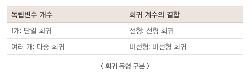

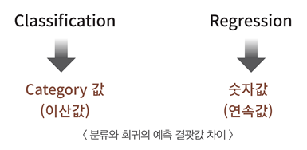

## 단순 선형 회귀를 통한 회귀 이해

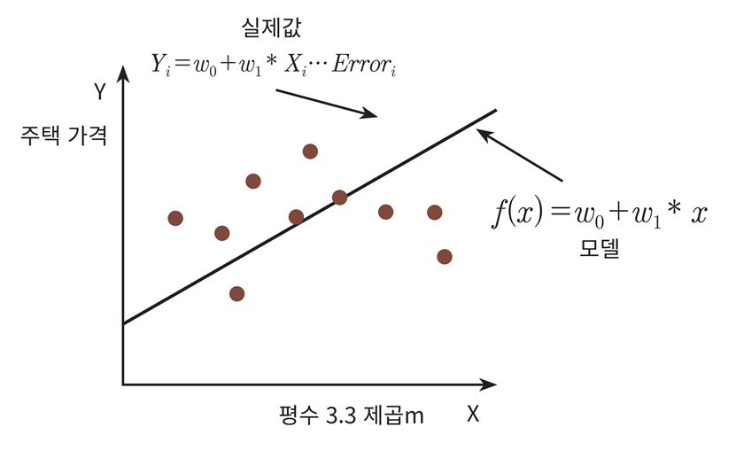

**Error**

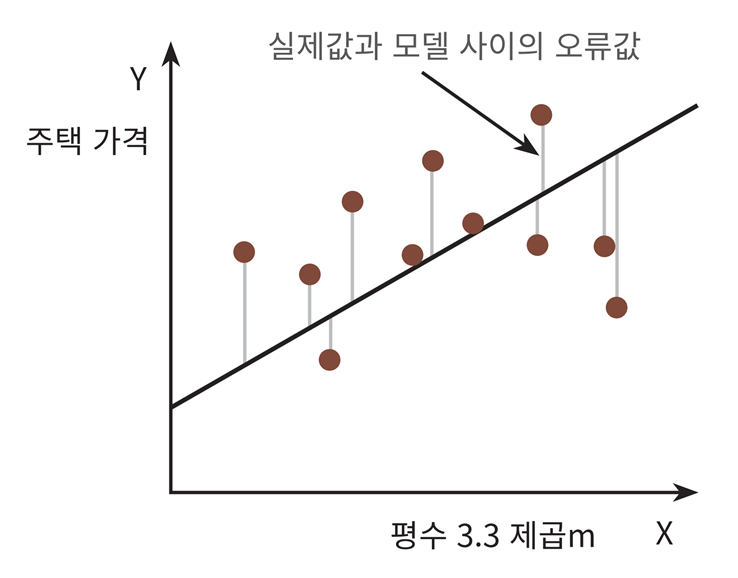

- 오류값은 +나 -가 될 수 있다. 따라서 (**오차의 합을 구하기 위해 단순히 더한다면 오류의 합이 작아질 수 있다.** )
- 이를 해결하기 위해서: (**절대값을 취해 더하**)거나, (**오류 값에 제곱을 구해서 합을 구**)한다.

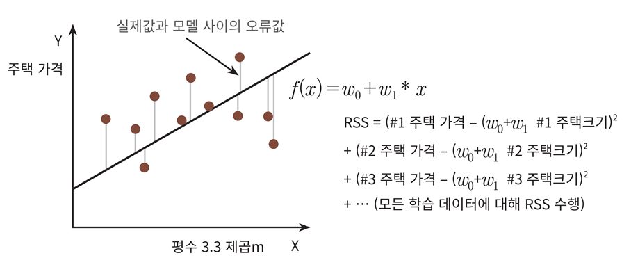

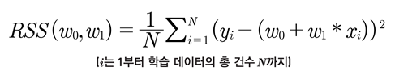

## 경사하강법(Gradient descen)

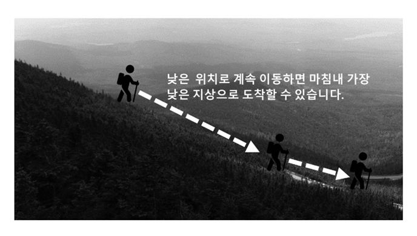

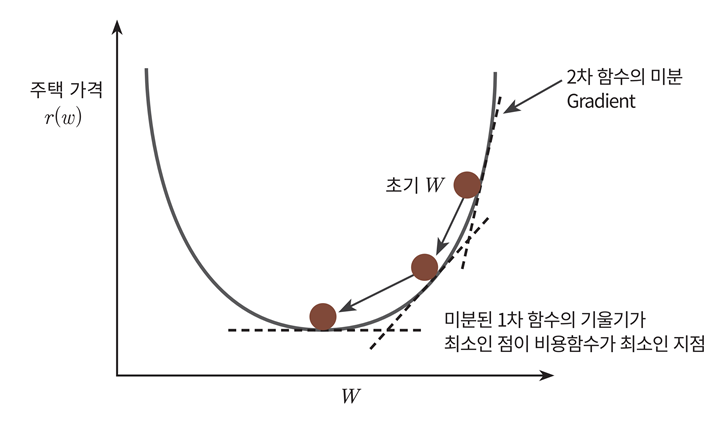

※ 편미분: https://m.blog.naver.com/sw4r/221946248471

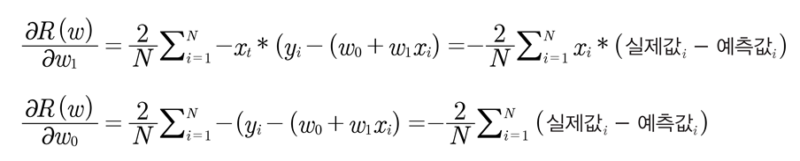

- step 1: 가중치와 절편을 임의의 값으로 설정 하고 첫 손실을 계산.
- step 2: 경사하강법을 이용해 가중치와 절편을 업데이트 한 후 다시 손실을 계산
- step 3: 가중치, 절편의 값이 변경되었으면 step2를 반복하고, 더 이상 가중치, 절편의 값이 변경 되지 않으면 반복을 중지한다.

## 특성이 여러개 일 경우

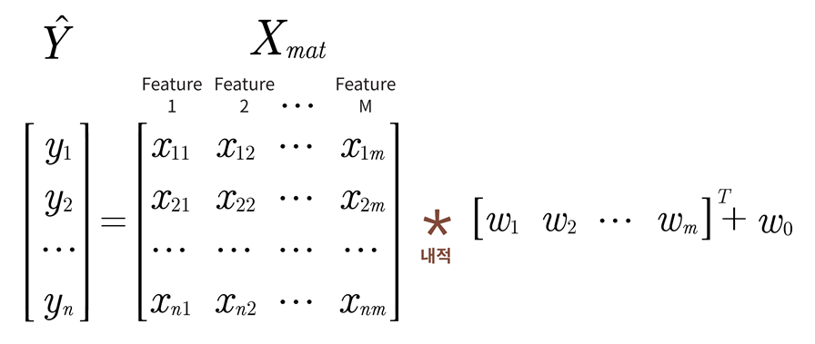

### 사이킷런 선형회귀 입력파라미터

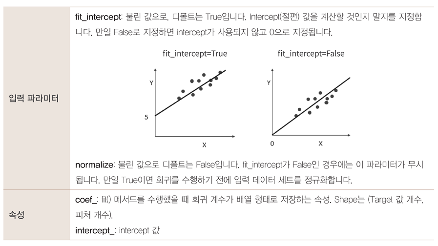

#### 회귀 평가지표

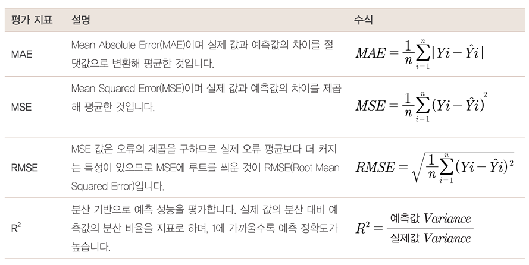

#### 평가지표 함수

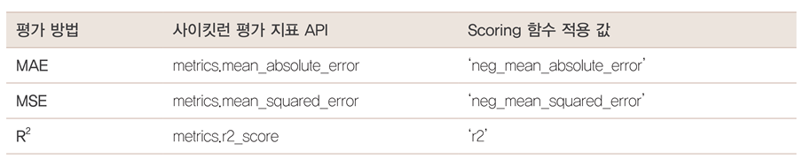

### 사이킷런 LinearRegression을 이용한 보스턴 주택 가격 예측

```python
import numpy as np
import matplotlib.pyplot as plt
import pandas as pd
import seaborn as sns
from scipy import stats
from sklearn.datasets import load_boston

#
boston = load_boston()

#
bostonDF = pd.DataFrame(boston.data , columns = boston.feature_names)

#
bostonDF['PRICE'] = boston.target
print('Boston 데이타셋 크기 :',bostonDF.shape)
bostonDF.head()
```

```
Boston 데이타셋 크기 : (506, 14)
```

|  | CRIM | ZN | INDUS | CHAS | NOX | RM | AGE | DIS | RAD | TAX | PTRATIO | B | LSTAT | PRICE |
| --- | --- | --- | --- | --- | --- | --- | --- | --- | --- | --- | --- | --- | --- | --- |
| 0 | 0.00632 | 18.0 | 2.31 | 0.0 | 0.538 | 6.575 | 65.2 | 4.0900 | 1.0 | 296.0 | 15.3 | 396.90 | 4.98 | 24.0 |
| 1 | 0.02731 | 0.0 | 7.07 | 0.0 | 0.469 | 6.421 | 78.9 | 4.9671 | 2.0 | 242.0 | 17.8 | 396.90 | 9.14 | 21.6 |
| 2 | 0.02729 | 0.0 | 7.07 | 0.0 | 0.469 | 7.185 | 61.1 | 4.9671 | 2.0 | 242.0 | 17.8 | 392.83 | 4.03 | 34.7 |
| 3 | 0.03237 | 0.0 | 2.18 | 0.0 | 0.458 | 6.998 | 45.8 | 6.0622 | 3.0 | 222.0 | 18.7 | 394.63 | 2.94 | 33.4 |
| 4 | 0.06905 | 0.0 | 2.18 | 0.0 | 0.458 | 7.147 | 54.2 | 6.0622 | 3.0 | 222.0 | 18.7 | 396.90 | 5.33 | 36.2 |

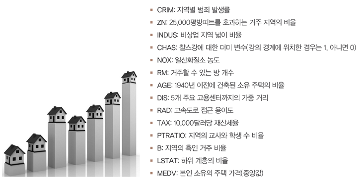

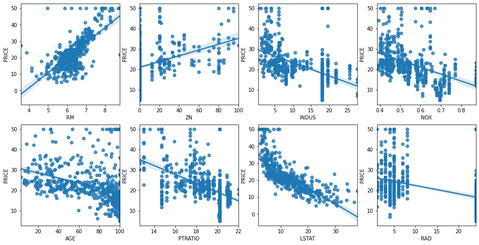

```python
# 2개의 행과 4개의 열을 가진 subplots를 이용. axs는 4x2개의 ax를 가짐.
fig, axs = plt.subplots(figsize=(16,8) , ncols=4 , nrows=2)
lm_features = ['RM','ZN','INDUS','NOX','AGE','PTRATIO','LSTAT','RAD']
for i , feature in enumerate(lm_features):
    row = int(i/4)
    col = i%4
    # 시본의 regplot을 이용해 산점도와 선형 회귀 직선을 함께 표현
    sns.regplot(x=feature , y='PRICE',data=bostonDF , ax=axs[row][col])
```

```python
from sklearn.model_selection import train_test_split
from sklearn.linear_model import LinearRegression
from sklearn.metrics import mean_squared_error , r2_score

y_target = bostonDF['PRICE']
X_data = bostonDF.drop(['PRICE'],axis=1,inplace=False)

X_train , X_test , y_train , y_test = train_test_split(X_data ,
                                                       y_target,
                                                       test_size=0.3,
                                                       random_state=156)

# Linear Regression 학습/예측/평가 수행.
lr = LinearRegression()
lr.fit(X_train ,y_train )
y_preds = lr.predict(X_test)
mse = mean_squared_error(y_test, y_preds)
rmse = np.sqrt(mse)

print('평균제곱오차(MSE) : {0:.3f} , 평균 제곱근 오차(RMSE) : {1:.3F}'.format(mse , rmse))
```

```
평균제곱오차(MSE) : 17.297 , 평균 제곱근 오차(RMSE) : 4.159
```

```python
print('절편 값:',lr.intercept_)
print('W 계수값:', np.round(lr.coef_, 1))
```

```
절편 값: 40.995595172164755
W 계수값: [ -0.1   0.1   0.    3.  -19.8   3.4   0.   -1.7   0.4  -0.   -0.9   0.
  -0.6]
```

```python
# 회귀 계수를 큰 값 순으로 정렬하기 위해 Series로 생성. index가 컬럼명에 유의
coeff = pd.Series(data = np.round(lr.coef_, 1),
                  index = X_data.columns )
coeff.sort_values(ascending=False)
```

```
RM          3.4
CHAS        3.0
RAD         0.4
ZN          0.1
B           0.0
TAX        -0.0
AGE         0.0
INDUS       0.0
CRIM       -0.1
LSTAT      -0.6
PTRATIO    -0.9
DIS        -1.7
NOX       -19.8
dtype: float64
```

```python
from sklearn.model_selection import cross_val_score

y_target = bostonDF['PRICE']
X_data = bostonDF.drop(['PRICE'],axis=1,inplace=False)
lr = LinearRegression()

# cross_val_score( )로 5 Fold 셋으로 MSE 를 구한 뒤 이를 기반으로 다시  RMSE 구함.
neg_mse_scores = cross_val_score(lr, X_data, y_target, scoring="neg_mean_squared_error", cv = 5)
rmse_scores  = np.sqrt(-1 * neg_mse_scores)
avg_rmse = np.mean(rmse_scores)

# cross_val_score(scoring="neg_mean_squared_error")로 반환된 값은 모두 음수
print(' 5 folds 의 개별 Negative MSE scores: ', np.round(neg_mse_scores, 2))
print(' 5 folds 의 개별 RMSE scores : ', np.round(rmse_scores, 2))
print(' 5 folds 의 평균 RMSE : {0:.3f} '.format(avg_rmse))
```

```
 5 folds 의 개별 Negative MSE scores:  [-12.46 -26.05 -33.07 -80.76 -33.31]
 5 folds 의 개별 RMSE scores :  [3.53 5.1  5.75 8.99 5.77]
 5 folds 의 평균 RMSE : 5.829
```

## 다항회귀와 오버피팅/언더피팅 이해

```python
from sklearn.preprocessing import PolynomialFeatures
import numpy as np

# 다항식으로 변환한 단항식 생성, [[0,1],[2,3]]의 2X2 행렬 생성
X = np.arange(4).reshape(2,2)
print('일차 단항식 계수 feature:\n',X )
```

```
일차 단항식 계수 feature:
 [[0 1]
 [2 3]]
```

```python
# degree = 2 인 2차 다항식으로 변환하기 위해 PolynomialFeatures를 이용하여 변환

poly = PolynomialFeatures(degree=2)
poly.fit(X)
poly_ftr = poly.transform(X)
print('변환된 2차 다항식 계수 feature:\n', poly_ftr)
```

```
변환된 2차 다항식 계수 feature:
 [[1. 0. 1. 0. 0. 1.]
 [1. 2. 3. 4. 6. 9.]]
```

### 다항회귀를 이용한 Underfitting, Overfitting 이해

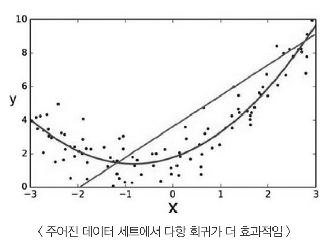

```python
# 임의의 데이터셋 생성
import numpy as np
import matplotlib.pyplot as plt
from sklearn.pipeline import Pipeline
from sklearn.preprocessing import PolynomialFeatures
from sklearn.linear_model import LinearRegression
from sklearn.model_selection import cross_val_score

# random 값으로 구성된 X값에 대해 Cosine 변환값을 반환.
def true_fun(X):
    return np.cos(1.5 * np.pi * X)

# X는 0 부터 1까지 30개의 random 값을 순서대로 sampling 한 데이타 입니다.
np.random.seed(0)
n_samples = 30
X = np.sort(np.random.rand(n_samples))

# y 값은 cosine 기반의 true_fun() 에서 약간의 Noise 변동값을 더한 값입니다.
y = true_fun(X) + np.random.randn(n_samples) * 0.1
```

[output not shown]

```python
def degree_Poly(deg):

  plt.figure(figsize=(7, 5))
  # 개별 degree별로 Polynomial 변환합니다.
  polynomial_features = PolynomialFeatures(degree=deg, include_bias=False)
  linear_regression = LinearRegression()
  pipeline = Pipeline([("polynomial_features", polynomial_features),
                        ("linear_regression", linear_regression)])
  pipeline.fit(X.reshape(-1, 1), y)

  # 교차 검증으로 다항 회귀를 평가합니다.
  scores = cross_val_score(pipeline, X.reshape(-1,1), y,scoring="neg_mean_squared_error", cv=10)
  coefficients = pipeline.named_steps['linear_regression'].coef_
  print('\nDegree {0} 회귀 계수는 {1} 입니다.'.format(deg, np.round(coefficients),2))
  print('Degree {0} MSE 는 {1:.2f} 입니다.'.format(deg , -1*np.mean(scores)))

  # 0 부터 1까지 테스트 데이터 세트를 100개로 나눠 예측을 수행합니다.
  # 테스트 데이터 세트에 회귀 예측을 수행하고 예측 곡선과 실제 곡선을 그려서 비교합니다.
  X_test = np.linspace(0, 1, 100)
  # 예측값 곡선
  plt.plot(X_test, pipeline.predict(X_test[:, np.newaxis]), label="Model")
  # 실제 값 곡선
  plt.plot(X_test, true_fun(X_test), '--', label="True function")
  plt.scatter(X, y, edgecolor='b', s=20, label="Samples")

  plt.xlabel("x"); plt.ylabel("y"); plt.xlim((0, 1)); plt.ylim((-2, 2)); plt.legend(loc="best")
  plt.title("Degree {}\nMSE = {:.2e}(+/- {:.2e})".format(deg, -scores.mean(), scores.std()))
```

```
Degree 1 회귀 계수는 [-2.] 입니다.
Degree 1 MSE 는 0.41 입니다.
```

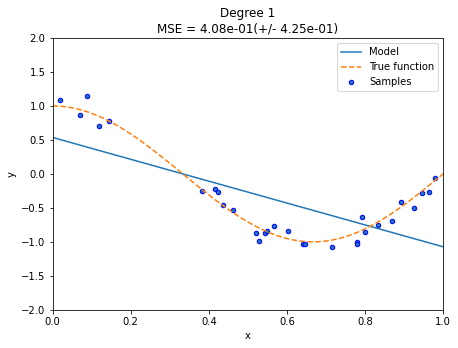

```python
degree_Poly(1)
```

```
Degree 4 회귀 계수는 [  0. -18.  24.  -7.] 입니다.
Degree 4 MSE 는 0.04 입니다.
```

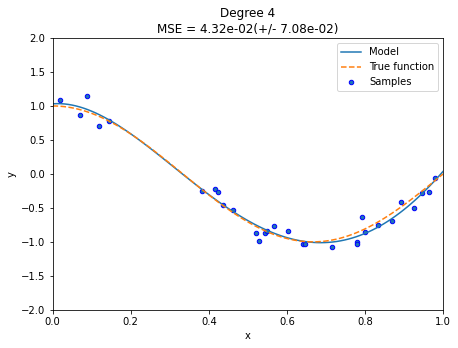

```python
degree_Poly(4)
```

```
Degree 15 회귀 계수는 [-2.98300000e+03  1.03899000e+05 -1.87415100e+06  2.03715130e+07
 -1.44872551e+08  7.09311979e+08 -2.47064676e+09  6.24558367e+09
 -1.15676035e+10  1.56894317e+10 -1.54005437e+10  1.06456871e+10
 -4.91375763e+09  1.35919168e+09 -1.70380199e+08] 입니다.
Degree 15 MSE 는 180526263.29 입니다.
```

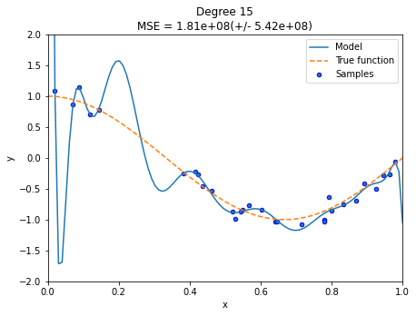

```python
degree_Poly(15)
```

### 규제 선형 모델 - 릿지, 라쏘

Degree가 1인 경우 예측곡선이 단순하여 과소적합을 하게 되고, Degree가 15인 경우 학습 데이터 샘플에 지나치게 적합한 곡선을 그려 과적합을 유발한다.

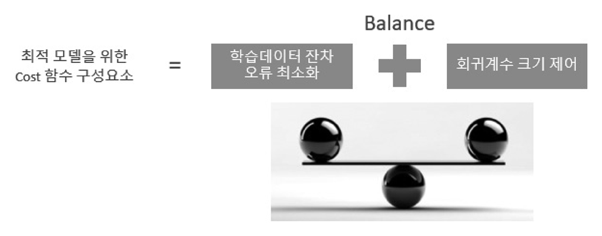

**Cost(비용함수) 변경**

- norm: 선형대수학에서 놈은 벡터의 크기(magnitude) 또는 길이(length)를 측정하는 방법을 의미  
  norm 참고자료: https://bskyvision.com/825

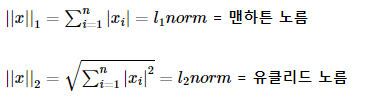

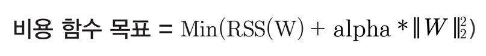

alpha는 학습 데이터 적합 정도와 회귀 계수 값을 크기 제어를 수행하는 튜닝 파라미터  
alpha를 0에서부터 지속적으로 값을 증가시키면 회귀 계수 값의 크기를 감소  
비용 함수에 alpha 값으로 패널티를 부여해 회귀 계수 값의크기를 감소시켜 과적합을 개선하는 방식을 규제(Regularization)라고 한다.

#### 릿지 회귀 ( Ridge Regression )

- 사이킷런은 Ridge 클래스를 통해 릿지 회귀를 구현합니다. 클래스의 주요 생성 파라미터는 alpha이며, 이는 릿지 회귀의 alpha L2 규제 계수에 해당

```python
import numpy as np
from sklearn.model_selection import train_test_split
import pandas as pd
from sklearn.datasets import load_boston

#
boston = load_boston()

#
bostonDF = pd.DataFrame(boston.data , columns = boston.feature_names)

#
bostonDF['PRICE'] = boston.target
print('Boston 데이타셋 크기 :',bostonDF.shape)

y_target = bostonDF['PRICE']
X_data = bostonDF.drop(['PRICE'],axis=1,inplace=False)

X_train , X_test , y_train , y_test = train_test_split(X_data ,
                                                       y_target,
                                                       test_size=0.3,
                                                       random_state=156)
```

```
Boston 데이타셋 크기 : (506, 14)
```

```python
from sklearn.linear_model import Ridge
from sklearn.model_selection import cross_val_score

ridge = Ridge(alpha = 10)
# cross_val_score():
# neg_mean_squared_error: 평균제곱오차의 루트를 씌운 평가 지표
neg_mse_scores = cross_val_score(ridge, X_data, y_target, scoring="neg_mean_squared_error", cv = 5)
rmse_scores  = np.sqrt(-1 * neg_mse_scores)
avg_rmse = np.mean(rmse_scores)
print(' 5 folds 의 개별 Negative MSE scores: ', np.round(neg_mse_scores, 3))
print(' 5 folds 의 개별 RMSE scores : ', np.round(rmse_scores,3))
print(' 5 folds 의 평균 RMSE : {0:.3f} '.format(avg_rmse))
```

```
 5 folds 의 개별 Negative MSE scores:  [-11.422 -24.294 -28.144 -74.599 -28.517]
 5 folds 의 개별 RMSE scores :  [3.38  4.929 5.305 8.637 5.34 ]
 5 folds 의 평균 RMSE : 5.518
```

```python
# Ridge에 사용될 alpha 파라미터의 값들을 정의
alphas = [0 , 0.1 , 1 , 10 , 100]

# alphas list 값을 iteration하면서 alpha에 따른 평균 rmse 구함.
for alpha in alphas :
    ridge = Ridge(alpha = alpha)

    #cross_val_score를 이용하여 5 fold의 평균 RMSE 계산
    neg_mse_scores = cross_val_score(ridge, X_data, y_target, scoring="neg_mean_squared_error", cv = 5)
    avg_rmse = np.mean(np.sqrt(-1 * neg_mse_scores))
    print('alpha {0} 일 때 5 folds 의 평균 RMSE : {1:.3f} '.format(alpha,avg_rmse))
```

```
alpha 0 일 때 5 folds 의 평균 RMSE : 5.829
alpha 0.1 일 때 5 folds 의 평균 RMSE : 5.788
alpha 1 일 때 5 folds 의 평균 RMSE : 5.653
alpha 10 일 때 5 folds 의 평균 RMSE : 5.518
alpha 100 일 때 5 folds 의 평균 RMSE : 5.330
```

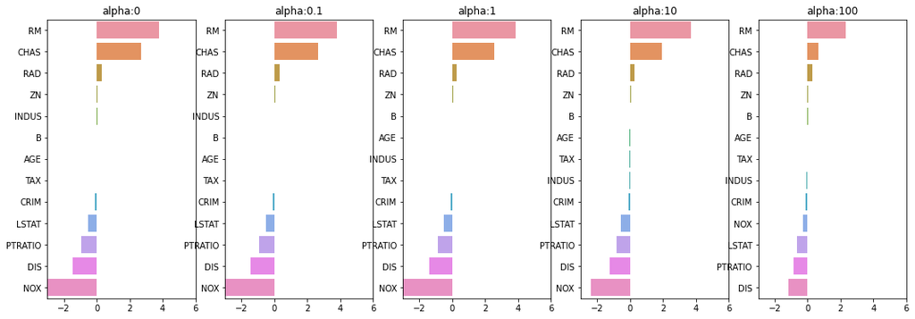

```python
import matplotlib.pyplot as plt
import seaborn as sns

# 각 alpha에 따른 회귀 계수 값을 시각화하기 위해 5개의 열로 된 맷플롯립 축 생성
fig , axs = plt.subplots(figsize=(18,6) , nrows=1 , ncols=5)
# 각 alpha에 따른 회귀 계수 값을 데이터로 저장하기 위한 DataFrame 생성
coeff_df = pd.DataFrame()

# alphas 리스트 값을 차례로 입력해 회귀 계수 값 시각화 및 데이터 저장. pos는 axis의 위치 지정
for pos , alpha in enumerate(alphas) :
    ridge = Ridge(alpha = alpha)
    ridge.fit(X_data , y_target)
    # alpha에 따른 피처별 회귀 계수를 Series로 변환하고 이를 DataFrame의 컬럼으로 추가.
    coeff = pd.Series(data=ridge.coef_ , index=X_data.columns )
    colname='alpha:'+str(alpha)
    coeff_df[colname] = coeff
    # 막대 그래프로 각 alpha 값에서의 회귀 계수를 시각화. 회귀 계수값이 높은 순으로 표현
    coeff = coeff.sort_values(ascending=False)
    axs[pos].set_title(colname)
    axs[pos].set_xlim(-3,6)
    sns.barplot(x=coeff.values , y=coeff.index, ax=axs[pos])

# for 문 바깥에서 맷플롯립의 show 호출 및 alpha에 따른 피처별 회귀 계수를 DataFrame으로 표시
plt.show()
```

```python
ridge_alphas = [0 , 0.1 , 1 , 10 , 100]
sort_column = 'alpha:'+str(ridge_alphas[0])
coeff_df.sort_values(by=sort_column, ascending=False)
```

|  | alpha:0 | alpha:0.1 | alpha:1 | alpha:10 | alpha:100 |
| --- | --- | --- | --- | --- | --- |
| RM | 3.809865 | 3.818233 | 3.854000 | 3.702272 | 2.334536 |
| CHAS | 2.686734 | 2.670019 | 2.552393 | 1.952021 | 0.638335 |
| RAD | 0.306049 | 0.303515 | 0.290142 | 0.279596 | 0.315358 |
| ZN | 0.046420 | 0.046572 | 0.047443 | 0.049579 | 0.054496 |
| INDUS | 0.020559 | 0.015999 | -0.008805 | -0.042962 | -0.052826 |
| B | 0.009312 | 0.009368 | 0.009673 | 0.010037 | 0.009393 |
| AGE | 0.000692 | -0.000269 | -0.005415 | -0.010707 | 0.001212 |
| TAX | -0.012335 | -0.012421 | -0.012912 | -0.013993 | -0.015856 |
| CRIM | -0.108011 | -0.107474 | -0.104595 | -0.101435 | -0.102202 |
| LSTAT | -0.524758 | -0.525966 | -0.533343 | -0.559366 | -0.660764 |
| PTRATIO | -0.952747 | -0.940759 | -0.876074 | -0.797945 | -0.829218 |
| DIS | -1.475567 | -1.459626 | -1.372654 | -1.248808 | -1.153390 |
| NOX | -17.766611 | -16.684645 | -10.777015 | -2.371619 | -0.262847 |

alpha 값이 커질수록 회귀 계수 값을 작아진다. 하지만 0이 되지는 않는다.

#### 라쏘 회귀 (Lasso Regression)

- L1규제는 불필요한 회귀 계수를 급격하게 감소시켜 0으로 만들어 제거
- L1규제는 적절한 피처만 회귀에 포함시키는 피처 선택의 특성을 가지고 있다.

```python
from sklearn.linear_model import Lasso
from sklearn.model_selection import cross_val_score

lasso = Lasso(alpha = 10)
neg_mse_scores = cross_val_score(lasso, X_data, y_target, scoring="neg_mean_squared_error", cv = 5)
rmse_scores  = np.sqrt(-1 * neg_mse_scores)
avg_rmse = np.mean(rmse_scores)
print(' 5 folds 의 개별 Negative MSE scores: ', np.round(neg_mse_scores, 3))
print(' 5 folds 의 개별 RMSE scores : ', np.round(rmse_scores,3))
print(' 5 folds 의 평균 RMSE : {0:.3f} '.format(avg_rmse))
```

```
 5 folds 의 개별 Negative MSE scores:  [-27.786 -46.397 -80.323 -61.56  -16.302]
 5 folds 의 개별 RMSE scores :  [5.271 6.812 8.962 7.846 4.038]
 5 folds 의 평균 RMSE : 6.586
```

```python
# lasso에 사용될 alpha 파라미터의 값들을 정의
lasso_alphas = [0.07, 0.1, 0.5, 1, 3]

# alphas list 값을 iteration하면서 alpha에 따른 평균 rmse 구함.
for alpha in lasso_alphas :
    lasso = Lasso(alpha = alpha)

    #cross_val_score를 이용하여 5 fold의 평균 RMSE 계산
    neg_mse_scores = cross_val_score(lasso, X_data, y_target, scoring="neg_mean_squared_error", cv = 5)
    avg_rmse = np.mean(np.sqrt(-1 * neg_mse_scores))
    print('alpha {0} 일 때 5 folds 의 평균 RMSE : {1:.3f} '.format(alpha,avg_rmse))
```

```
alpha 0.07 일 때 5 folds 의 평균 RMSE : 5.612
alpha 0.1 일 때 5 folds 의 평균 RMSE : 5.615
alpha 0.5 일 때 5 folds 의 평균 RMSE : 5.669
alpha 1 일 때 5 folds 의 평균 RMSE : 5.776
alpha 3 일 때 5 folds 의 평균 RMSE : 6.189
```

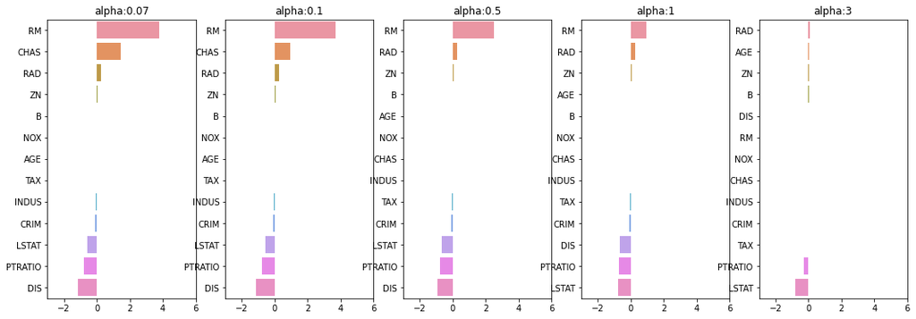

```python
import matplotlib.pyplot as plt
import seaborn as sns

# 각 alpha에 따른 회귀 계수 값을 시각화하기 위해 5개의 열로 된 맷플롯립 축 생성
fig , axs = plt.subplots(figsize=(18,6) , nrows=1 , ncols=5)
# 각 alpha에 따른 회귀 계수 값을 데이터로 저장하기 위한 DataFrame 생성
coeff_df = pd.DataFrame()

# alphas 리스트 값을 차례로 입력해 회귀 계수 값 시각화 및 데이터 저장. pos는 axis의 위치 지정
for pos , alpha in enumerate(lasso_alphas) :
    lasso = Lasso(alpha = alpha)
    lasso.fit(X_data , y_target)
    # alpha에 따른 피처별 회귀 계수를 Series로 변환하고 이를 DataFrame의 컬럼으로 추가.
    coeff = pd.Series(data=lasso.coef_ , index=X_data.columns )
    colname='alpha:'+str(alpha)
    coeff_df[colname] = coeff
    # 막대 그래프로 각 alpha 값에서의 회귀 계수를 시각화. 회귀 계수값이 높은 순으로 표현
    coeff = coeff.sort_values(ascending=False)
    axs[pos].set_title(colname)
    axs[pos].set_xlim(-3,6)
    sns.barplot(x=coeff.values , y=coeff.index, ax=axs[pos])

# for 문 바깥에서 맷플롯립의 show 호출 및 alpha에 따른 피처별 회귀 계수를 DataFrame으로 표시
plt.show()
```

```python
lasso_alphas = [ 0.07, 0.1, 0.5, 1, 3]
sort_column = 'alpha:'+str(lasso_alphas[0])
coeff_df.sort_values(by=sort_column, ascending=False)
```

|  | alpha:0.07 | alpha:0.1 | alpha:0.5 | alpha:1 | alpha:3 |
| --- | --- | --- | --- | --- | --- |
| RM | 3.789725 | 3.703202 | 2.498212 | 0.949811 | 0.000000 |
| CHAS | 1.434343 | 0.955190 | 0.000000 | 0.000000 | 0.000000 |
| RAD | 0.270936 | 0.274707 | 0.277451 | 0.264206 | 0.061864 |
| ZN | 0.049059 | 0.049211 | 0.049544 | 0.049165 | 0.037231 |
| B | 0.010248 | 0.010249 | 0.009469 | 0.008247 | 0.006510 |
| NOX | -0.000000 | -0.000000 | -0.000000 | -0.000000 | 0.000000 |
| AGE | -0.011706 | -0.010037 | 0.003604 | 0.020910 | 0.042495 |
| TAX | -0.014290 | -0.014570 | -0.015442 | -0.015212 | -0.008602 |
| INDUS | -0.042120 | -0.036619 | -0.005253 | -0.000000 | -0.000000 |
| CRIM | -0.098193 | -0.097894 | -0.083289 | -0.063437 | -0.000000 |
| LSTAT | -0.560431 | -0.568769 | -0.656290 | -0.761115 | -0.807679 |
| PTRATIO | -0.765107 | -0.770654 | -0.758752 | -0.722966 | -0.265072 |
| DIS | -1.176583 | -1.160538 | -0.936605 | -0.668790 | -0.000000 |

#### 엘라스틱넷 회귀 (Elastic Net Regression)

- L1 규제와 L2 규제를 결합한 회귀

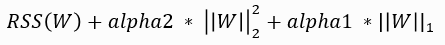

```python
from sklearn.linear_model import ElasticNet
from sklearn.model_selection import cross_val_score

elastic = ElasticNet(alpha = 10, l1_ratio = 0.7)
neg_mse_scores = cross_val_score(elastic, X_data, y_target, scoring="neg_mean_squared_error", cv = 5)
rmse_scores  = np.sqrt(-1 * neg_mse_scores)
avg_rmse = np.mean(rmse_scores)
print(' 5 folds 의 개별 Negative MSE scores: ', np.round(neg_mse_scores, 3))
print(' 5 folds 의 개별 RMSE scores : ', np.round(rmse_scores,3))
print(' 5 folds 의 평균 RMSE : {0:.3f} '.format(avg_rmse))
```

```
 5 folds 의 개별 Negative MSE scores:  [-26.796 -44.347 -78.799 -60.676 -16.344]
 5 folds 의 개별 RMSE scores :  [5.177 6.659 8.877 7.789 4.043]
 5 folds 의 평균 RMSE : 6.509
```

```python
# lasso에 사용될 alpha 파라미터의 값들을 정의
elastic_alphas = [0.07, 0.1, 0.5, 1, 3]

# alphas list 값을 iteration하면서 alpha에 따른 평균 rmse 구함.
for alpha in elastic_alphas :
    elastic = ElasticNet(alpha = alpha, l1_ratio = 0.7)

    #cross_val_score를 이용하여 5 fold의 평균 RMSE 계산
    neg_mse_scores = cross_val_score(elastic, X_data, y_target, scoring="neg_mean_squared_error", cv = 5)
    avg_rmse = np.mean(np.sqrt(-1 * neg_mse_scores))
    print('alpha {0} 일 때 5 folds 의 평균 RMSE : {1:.3f} '.format(alpha,avg_rmse))
```

```
alpha 0.07 일 때 5 folds 의 평균 RMSE : 5.542
alpha 0.1 일 때 5 folds 의 평균 RMSE : 5.526
alpha 0.5 일 때 5 folds 의 평균 RMSE : 5.467
alpha 1 일 때 5 folds 의 평균 RMSE : 5.597
alpha 3 일 때 5 folds 의 평균 RMSE : 6.068
```

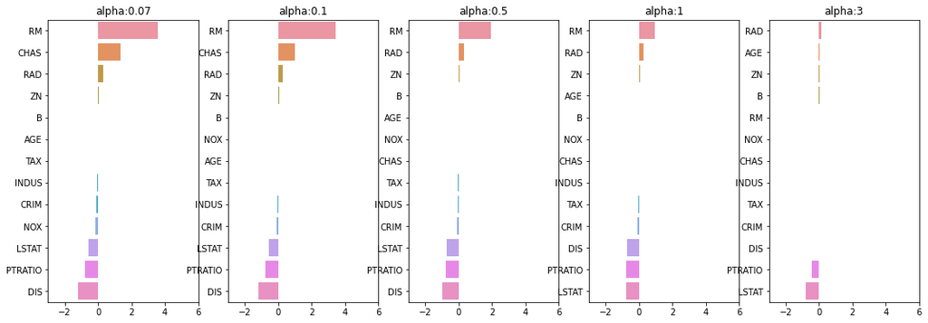

```python
import matplotlib.pyplot as plt
import seaborn as sns

# 각 alpha에 따른 회귀 계수 값을 시각화하기 위해 5개의 열로 된 맷플롯립 축 생성
fig , axs = plt.subplots(figsize=(18,6) , nrows=1 , ncols=5)
# 각 alpha에 따른 회귀 계수 값을 데이터로 저장하기 위한 DataFrame 생성
coeff_df = pd.DataFrame()

# alphas 리스트 값을 차례로 입력해 회귀 계수 값 시각화 및 데이터 저장. pos는 axis의 위치 지정
for pos , alpha in enumerate(elastic_alphas) :
    elastic = ElasticNet(alpha = alpha, l1_ratio = 0.7)
    elastic.fit(X_data , y_target)
    # alpha에 따른 피처별 회귀 계수를 Series로 변환하고 이를 DataFrame의 컬럼으로 추가.
    coeff = pd.Series(data=elastic.coef_ , index=X_data.columns )
    colname='alpha:'+str(alpha)
    coeff_df[colname] = coeff
    # 막대 그래프로 각 alpha 값에서의 회귀 계수를 시각화. 회귀 계수값이 높은 순으로 표현
    coeff = coeff.sort_values(ascending=False)
    axs[pos].set_title(colname)
    axs[pos].set_xlim(-3,6)
    sns.barplot(x=coeff.values , y=coeff.index, ax=axs[pos])

# for 문 바깥
plt.show()
```

```python
elastic_alphas = [ 0.07, 0.1, 0.5, 1, 3]
sort_column = 'alpha:'+str(elastic_alphas[0])
coeff_df.sort_values(by=sort_column, ascending=False)
```

|  | alpha:0.07 | alpha:0.1 | alpha:0.5 | alpha:1 | alpha:3 |
| --- | --- | --- | --- | --- | --- |
| RM | 3.574162 | 3.414154 | 1.918419 | 0.938789 | 0.000000 |
| CHAS | 1.330724 | 0.979706 | 0.000000 | 0.000000 | 0.000000 |
| RAD | 0.278880 | 0.283443 | 0.300761 | 0.289299 | 0.146846 |
| ZN | 0.050107 | 0.050617 | 0.052878 | 0.052136 | 0.038268 |
| B | 0.010122 | 0.010067 | 0.009114 | 0.008320 | 0.007020 |
| AGE | -0.010116 | -0.008276 | 0.007760 | 0.020348 | 0.043446 |
| TAX | -0.014522 | -0.014814 | -0.016046 | -0.016218 | -0.011417 |
| INDUS | -0.044855 | -0.042719 | -0.023252 | -0.000000 | -0.000000 |
| CRIM | -0.099468 | -0.099213 | -0.089070 | -0.073577 | -0.019058 |
| NOX | -0.175072 | -0.000000 | -0.000000 | -0.000000 | -0.000000 |
| LSTAT | -0.574822 | -0.587702 | -0.693861 | -0.760457 | -0.800368 |
| PTRATIO | -0.779498 | -0.784725 | -0.790969 | -0.738672 | -0.423065 |
| DIS | -1.189438 | -1.173647 | -0.975902 | -0.725174 | -0.031208 |

### 선형 회귀 모델을 위한 데이터 변환

- 선형회귀는 피처와 타겟(라벨) 간의 선형관계가 있다는 가정하고, 최적의 선형함수를 찾아 예측을 한다.
- 선형 회귀 모델은 타겟 값의 분포가 가우시안 정규분포 형태를 선호한다.
- 선형화귀는 타겟값과 피처값의 분포가 어느 한쪽으로 치우친 왜곡 형태의 분포일 경우 예측 성능에 부정적인 영향을 갖는다.

※ 따라서 일반적으로 선형회귀를 사용할 경우 학습전 데이터 셋을 정규화/스케일링 작업을 선행한다.

**일반적으로 피처 데이터 셋과 타겟 데이터 셋은 스케일링/정규화 하는 방법이 다르다.**

- 피쳐 데이터 셋 스케일링/정규화
  1. StandadScaler 클래스를 이용해 평균이 0, 분산이 1인 정규분포룰 가진 데이터 셋으로 변환하거나 MaxMinScaler 클래스를 이용해 최소값이 0이고 최대값이 1인 값으로 정규화 한다.
  2. 스케일링/정규화를 한 데이터 셋트에 다시 다항 특성을 적용하는 방법. 보통 1번을 수행하고 성능에 향상이 없을 경우 사용하지만, 과적합의 위험이 크다.
  3. 원본 데이터 값에 log를 취함으로써 정규분포에 가까운 형태로 값이 분포 된다. 이러한 변환을 log Transformating 라고 하며, 선형회귀에서 많이 사용 되는 방법이다.
- 타겟 데이터 셋 스케일링/정규화
  1. StandadScaler와 log Transformating을 사용 할 수 있지만 보통 log Transformating를 많이 사용.

```python
from sklearn.preprocessing import StandardScaler, MinMaxScaler, PolynomialFeatures

# method는 표준 정규 분포 변환(Standard), 최대값/최소값 정규화(MinMax), 로그변환(Log) 결정
# p_degree는 다향식 특성을 추가할 때 적용. p_degree는 2이상 부여하지 않음.
def get_scaled_data(method='None', p_degree=None, input_data=None):
    if method == 'Standard':
        scaled_data = StandardScaler().fit_transform(input_data)
    elif method == 'MinMax':
        scaled_data = MinMaxScaler().fit_transform(input_data)
    elif method == 'Log':
        scaled_data = np.log1p(input_data) # 일반적으로 log()함수를 적용하면 언더플로우가 발생할 수 있어서 1+log()를 사용
    else:
        scaled_data = input_data

    if p_degree != None:
        scaled_data = PolynomialFeatures(degree=p_degree,
                                         include_bias=False).fit_transform(scaled_data)

    return scaled_data
```

```python
from sklearn.linear_model import Ridge

# Ridge의 alpha값을 다르게 적용하고 다양한 데이터 변환방법에 따른 RMSE 추출.
alphas = [0.1, 1, 10, 100]
#변환 방법은 모두 6개, 원본 그대로, 표준정규분포, 표준정규분포+다항식 특성
# 최대/최소 정규화, 최대/최소 정규화+다항식 특성, 로그변환
scale_methods=[(None, None), ('Standard', None), ('Standard', 2),
               ('MinMax', None), ('MinMax', 2), ('Log', None)]
for scale_method in scale_methods:
    X_data_scaled = get_scaled_data(method=scale_method[0], p_degree=scale_method[1],
                                    input_data=X_data)
    print(X_data_scaled.shape, X_data.shape)
    print('\n## 변환 유형: {0}, Polynomial Degree: {1}'.format(scale_method[0], scale_method[1]))

    for alpha in alphas :
      ridge = Ridge(alpha = alpha)
      #cross_val_score를 이용하여 5 fold의 평균 RMSE 계산
      neg_mse_scores = cross_val_score(ridge,
                                       X_data_scaled,
                                       y_target,
                                       scoring="neg_mean_squared_error",
                                       cv = 5)
      avg_rmse = np.mean(np.sqrt(-1 * neg_mse_scores))
      print('alpha {0} 일 때 5 folds 의 평균 RMSE : {1:.3f} '.format(alpha,avg_rmse))
```

```
(506, 13) (506, 13)

## 변환 유형: None, Polynomial Degree: None
alpha 0.1 일 때 5 folds 의 평균 RMSE : 5.788
alpha 1 일 때 5 folds 의 평균 RMSE : 5.653
alpha 10 일 때 5 folds 의 평균 RMSE : 5.518
alpha 100 일 때 5 folds 의 평균 RMSE : 5.330
(506, 13) (506, 13)

## 변환 유형: Standard, Polynomial Degree: None
alpha 0.1 일 때 5 folds 의 평균 RMSE : 5.826
alpha 1 일 때 5 folds 의 평균 RMSE : 5.803
alpha 10 일 때 5 folds 의 평균 RMSE : 5.637
alpha 100 일 때 5 folds 의 평균 RMSE : 5.421
(506, 104) (506, 13)

## 변환 유형: Standard, Polynomial Degree: 2
alpha 0.1 일 때 5 folds 의 평균 RMSE : 8.827
alpha 1 일 때 5 folds 의 평균 RMSE : 6.871
alpha 10 일 때 5 folds 의 평균 RMSE : 5.485
alpha 100 일 때 5 folds 의 평균 RMSE : 4.634
(506, 13) (506, 13)

## 변환 유형: MinMax, Polynomial Degree: None
alpha 0.1 일 때 5 folds 의 평균 RMSE : 5.764
alpha 1 일 때 5 folds 의 평균 RMSE : 5.465
alpha 10 일 때 5 folds 의 평균 RMSE : 5.754
alpha 100 일 때 5 folds 의 평균 RMSE : 7.635
(506, 104) (506, 13)

## 변환 유형: MinMax, Polynomial Degree: 2
alpha 0.1 일 때 5 folds 의 평균 RMSE : 5.298
alpha 1 일 때 5 folds 의 평균 RMSE : 4.323
alpha 10 일 때 5 folds 의 평균 RMSE : 5.185
alpha 100 일 때 5 folds 의 평균 RMSE : 6.538
(506, 13) (506, 13)

## 변환 유형: Log, Polynomial Degree: None
alpha 0.1 일 때 5 folds 의 평균 RMSE : 4.770
alpha 1 일 때 5 folds 의 평균 RMSE : 4.676
alpha 10 일 때 5 folds 의 평균 RMSE : 4.836
alpha 100 일 때 5 folds 의 평균 RMSE : 6.241
```